# Data Mining(2021)-MidTerm Report

72200117 Kim Hee Ju

2021 4 26

*Title: “Data Mining(2021)-MidTerm Report”*  
*Author: “72200117 Kim Hee Ju”*  
*Due date: ‘2021 4 28’*

#### **시작하기 전에..**

> 현재 R Markdown 내부 오류 중 Knitr 라이브러리와 관련된 이슈가 발생하였습니다.Chunk가 실행이 되는 도중 Object를 찾지 못하는 에러가 발생했고, 이로 인해 현재 제 다양한 라이브러리와 참조변수가 많이 짜여져 있는 제 코드를 MArkdown v2에서는 Chunk단위로 실행시키기가 어려워 Data의 구성과 함께 설명드리며 결과를 보여드리기 불가한 점 미리 양해부탁드립니다.  
> 해당 이슈를 해결하기 위해해 문서를 찾아보는 중에, Markdown v1이후 kntir 패키지를 더 이상 따로 지원을 하지 않아 발생하는 오류 중 하나라고 하였습니다.  
> 만약 비슷한 이슈가 있는 학생이 있거나, 솔루션을 아신다면 조언 부탁드립니다.  
> 본 이슈를 찾아보면서 참고했던 링크를 함께 첨부해드립니다.
- https://rmarkdown.rstudio.com/authoring_migrating_from_v1.html
- https://community.rstudio.com/t/knitting-issue-object-not-found/23448
- https://github.com/yihui/knitr/issues/445

## **Topic : 혼인 요소에 영향을 미치는 요인 분석 및 시각화**

> 본 과제의 데이터로 사용된 자료는 한국보건사회연구원에서 가구 경제활동을 연구해 정책 지원에 반영할 목적으로 발간하는 조사 자료인 **한국복지패널데이터**를 2015년부터 2020년, 총 6개년의 자료를 추적한 후, 이를 취합 및 가공한 것으로 사용하였였다. 이를 통해 현재 혼인과 관련된 시간적, 지역적 현황/추이를 살펴보고, 연관성이 있어 보이는 요소를 탐색하였다.
- 다운로드 링크 https://www.koweps.re.kr:442/main.do

### **1. 데이터 분석 준비 - 타입, 패키지, 라이브러리**

| sav | 행 개수 | 변수 개수 |
| --- | --- | --- |
| *Koweps_2015* | 16664 | 1155 |
| *Koweps_2016* | 15989 | 1155 |
| … | … | … |

해당 데이터는 세 종류의 파일(SPSS, SAS, STATA)로 제공되었으며, `SPSS` 전용 파일을 선택하였다.  
이번 데이터 분석을 위해 사용된 라이브러리는 다음과 같다.

```r
library("foreign") #SPSS 파일 불러오기

library("MASS") #dplyr 전처리 오류 발생 이전 반드시 실행시켜주어야 함

library("dplyr") #전처리
library("ggplot2") #시각화
library("readxl") #엑셀불러오기
library("descr") #관측치 탐색
library("plyr") #데이터 분할, 적용, 조합
library("gridExtra") #ggplot2 다중 분할 및 게시
```

### **2.데이터 전처리 및 분석 절차**

해당 데이터들은 설문조사를 기반으로 한 데이터이며, 해 마다 일부 문항들에 대해 문항내용 및 답변이 바뀌기 때문에 사전에 제공되는 `Codebook`을 통해 변수를 확인/검수 해야한다. 이를 토대로 이번 시각화 및 분석에 필요한 변수들을 선별한 후, 분석 방향에 맞추어 정리한다.

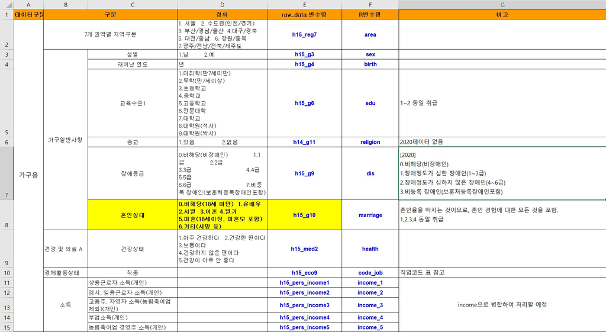

EditCodebook

이번 시각화 및 분석에 사용할 변수는 다음과 같이 선별하였다.

```r
#2019 데이터셋 가공
welfare.2019 <- rename(welfare.2019,
                       sex=h14_g3,#성별
                       area=h14_reg7, #지역코드
                       birth=h14_g4, #태어난 년도
                       edu=h14_g6, #교육수준
                       religion=h14_g11, #종교
                       dis=h14_g9,#장애수준
                       marriage=h14_g10, #혼인상태
                       health=h14_med2, #건강수준
                       code_job=h14_eco9, #직종
                       income_1=h14_pers_income1, #상용근로자 소득
                       income_2=h14_pers_income2, #일용근로자 소득
                       income_3=h14_pers_income3, #자영업자 소득(농림축어업 외)
                       income_4=h14_pers_income4, #부업소득
                       income_5=h14_pers_income5) #농림축어업 소득
```

여기서 소득과 같은 부분은 각각 분리가 되어 있어 병합하여 하나의 변수로 활용하기 위해 다음과 같이 작업하였다.

```r
income <- coalesce(welfare.2019$income_1,
                   welfare.2019$income_2,
                   welfare.2019$income_3,
                   welfare.2019$income_4,
                   welfare.2019$income_5)
```

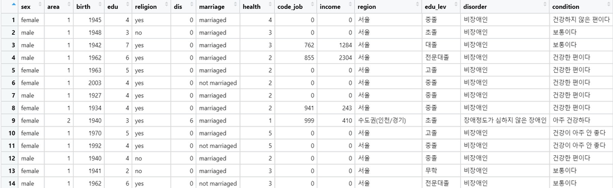

welfare.2019

해당 작업은 2015년 파일부터 총 2020년 파일까지 모두 진행해 주었으며, 2020년도엔 종교 여부를 물어보는 문항이 빠졌다는 특이사항이 있어 종교가 포함이 된 데이터셋은 따로 생성하였다.

### **3.전체 데이터 시각화-hist()**

- **year** : 각 년마다 사람들이 설문조사에 참여한 인원 수를 확인할 수 있었음. 감소 추세
- **sex** : 남(=1), 여(=2)을 나타내며, 여자가 더 많이 참여하였음.
- **area** : 7개 광역시/도를 기준으로 참여한 인원수를 확인할 수 있었음.
- **birth** : 출생년도에 대한 분포도를 알 수 있으며, 중장년층이 많이 참여한 설문이었음.
- **edu, dis, health** : 교육수준/장애수준/건강수준에 대한 단계별로 응답한 분포임.
- **religion** : 종교의 유(=1), 무(=2)를 나타내며, 가지지 않은 자가 더 많았음.
- **marriage** : 혼인, 사별, 이혼, 미혼 등 여러 형태의 모습을 나타내고 있으며, 혼인 경험을 1회라고 가졌던 자에 한해 모두 혼인률에 포함시켰음.
- **code_job** : 직업별 부여된 코드를 통해 어느 직군 사람들이 참여하였는지 알 수 있었음. 경제활동을 하지 않는 미성년자 및 노년층이 모두 포함되어 있기 때문에 `code_job = 0`인 `무직`상태가 가장 수가 높았음.

그러나 데이터를 편집하는 중에 `Income(소득)` 데이터를 다루는 부분에서 이상치를 처리하는데에 있어 디테일한 처리가 어려웠고, `boxplot()`을 통해 분석을 하고 싶었으나 제대로된 plot이 나타나지 않아 분석이 불가하였다.

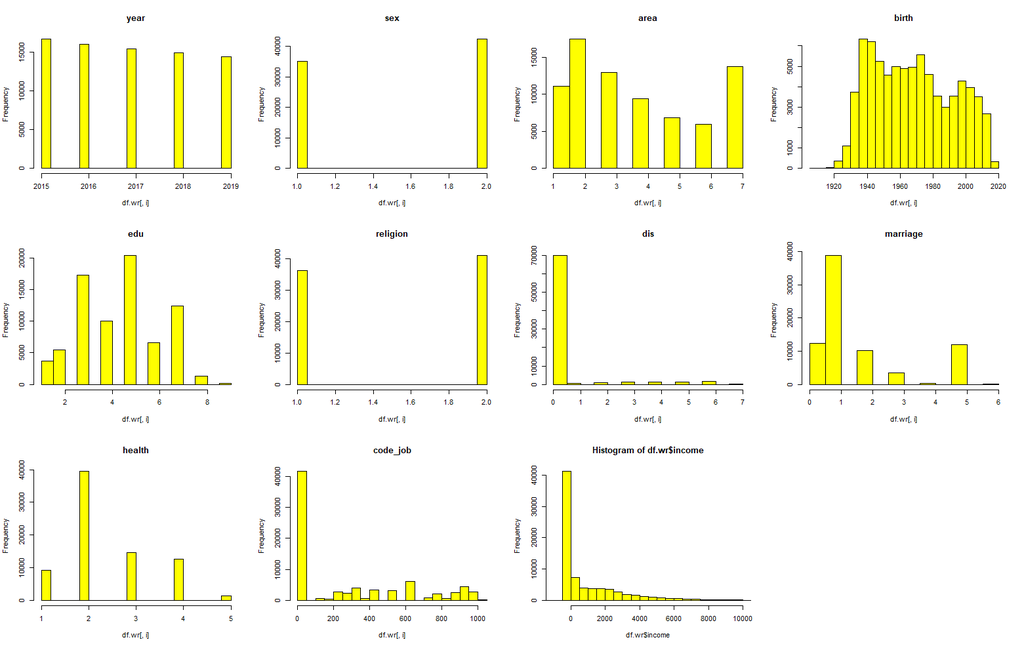

```r
###0. 전체 히스토그램 확인

###혼인율 결정 요인 데이터 분석자료 생성

##all hist
df.wr <- rbind(df.wr.2015, df.wr.2016, df.wr.2017, df.wr.2018, df.wr.2019)
df.wr.outlier <- df.wr

#법적 혼인 불가 미성년자 제거
df.wr.outlier$birth <- ifelse(df.wr.outlier$birth > 2002 , NA, df.wr.outlier$birth)
df.wr.outlier <- df.wr.outlier[which(!df.wr.outlier$birth %in% NA),]

#boxplot(income~year, data=df.wr.outlier, main="연도별 임금 현황")$stats #이상치 처리를 위한 통계 확인
#df.wr.outlier$income <- ifelse(df.wr.outlier$income < 0 | df.wr.outlier$income > 2500 , NA, df.wr.outlier$income)


par(mfrow=c(3,4))
for(i in 1:10){
  hist(df.wr[,i], main=colnames(df.wr)[i], col="yellow")
}

##hist Income~region
hist(df.wr$income, breaks=1000, xlim = c(-1000, 10000), col="yellow")

par(mfrow=c(1,1))
```

이후에도 그래프를 보았을 때, 아무리 법정 혼인불가 인원을 제했음에도 불구하고, 연 소득이 0~1000(만원)미만의 인구가 많은 까닭은, 경제활동 가능 인구에서 제외된 노년층들도 모두 포함이 되어 있기 때문이다.

그러나 혼인률에는 이미 결혼을 했으나 이혼을 한 자, 사별을 한 자 등 현재 배우자가 없어도 혼인을 했었던 경험이 있으면 모두 포함을 시키기 때문에 노년층이 해당되는 것이 맞다고 판단하였고, 해당 데이터들은 모두 유효하다고 판단하였다.

### **4.연간 혼인률 추세 분석**

각 요인별 혼인률과의 상관관계를 분석하기 전, 현재 혼인률이 어떤 추세를 보이고 있는지 살펴보았다. 현재 2015년도부터 2020년까지 2%이내의 뚜렷한 상승폭은 아니지만, 상승하고 있는 추세를 보이고 있음을 알 수 있었다. 2019년에서 2020년 사이에 급격하게 기울기가 증가함을 알 수 있었다.

```r
freq(df.2019$marriage) #Frequency Percent 동시에 계산해서 보여줌

freq(df.2020$marriage)
```

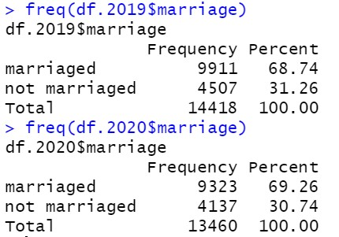

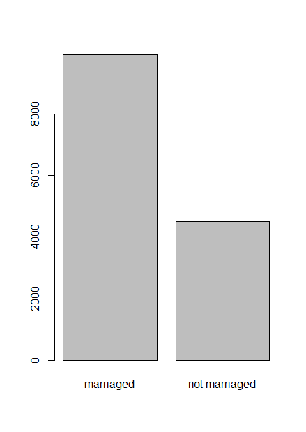

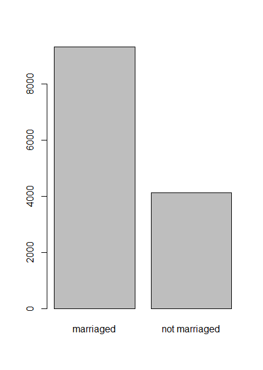

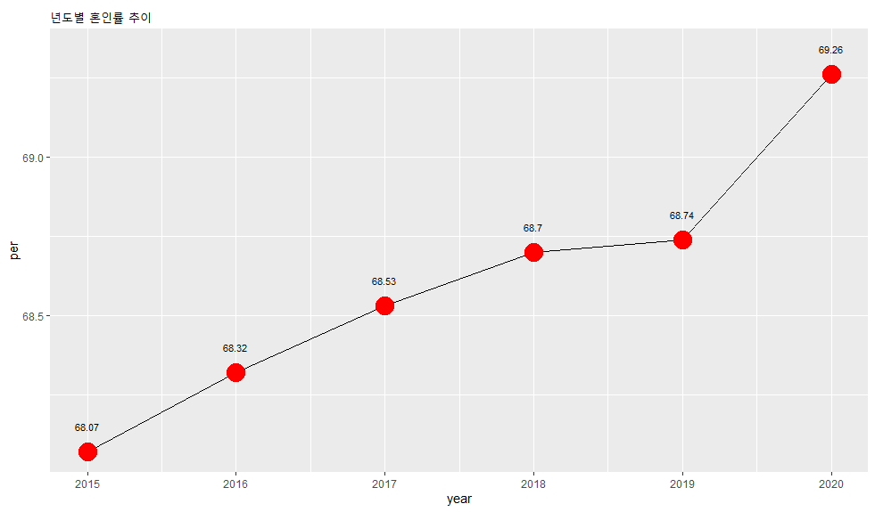

```r
####년도에 따른 혼인율 경향 분석

...
ggplot(data=df.marriage,
       aes(x=year,
           y=per))+
  ggtitle("년도별 혼인률 추이")+
  geom_line()+
  geom_point(size=7, shape=19, alpha=1.0, col="red")+
  geom_text(data=df.marriage,
            aes(x=year,
                y=per+0.08),
            size=3,
            label=per)
```

### **5.지역에 따른 시각화 및 분석**

혼인률과의 상관성을 따지기위해 우선 가장 먼저 지역과 관련하여 시각화를 시도했다.

지역별 데이터를 처리하기 위해 다음과 같이 전처리를 하였다.

```r
#area : 각 지역이 현재 Code로 분류되어 있어 알아보기 쉽게 문자표기도 함께 기입

list_region <- data.frame(area = c(1:7),
                          region= c("서울",
                                    "수도권(인천/경기)",
                                    "부산/경남/울산",
                                    "대구/경북",
                                    "대전/충남",
                                    "강원/충북",
                                    "광주/전남/전북/제주도"))
list_region
welfare.2015 <- left_join(welfare.2015, list_region, id="area")
```

#### **(1) 연도-지역별 설문 참여 그래프**

각 년도마다 지역에서 참여한 인원 수를 우선 시각화 하였다. 매년 설문조사 참여 인원수가 감소추세였기 때문에, 전국적으로 인원들이 감소추세를 함께 따라가고 있는 경향을 보이고 있다. 이는 두 가지 요인으로 추정된다.

1. *가구수를 함께 조사하는 설문조사의 특성상, **출산률**의 하락으로 인한 영향*
2. *2019년 **`광주/전남/전북/제주도`**의 급격한 감소를 보이는 기울기를 토대로 보았을 때, **COVID-19** 등으로 인한 설문 조사 진행의 어려움으로 인한 영향*

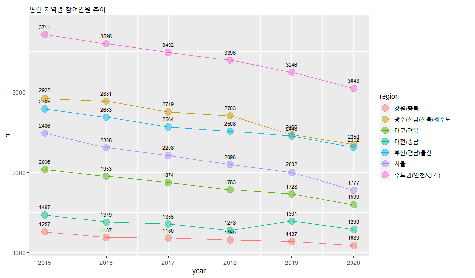

```r
ggplot(df.region_cnt,aes(x=year.r, y=n ,colour=region, group=region))+
  geom_line()+geom_point(size=5, shape=19, alpha=0.5)+
  ggtitle("연간 지역별 참여인원 추이")+
  ylab("n")+xlab("year")+
  geom_text(data = df.region_cnt,
            aes(x=year.r, y=n+100),
            size=3, col="black", label=df.region_cnt$n)
```

#### **(2) 지역별 총 설문 참여 그래프**

년도와 상관없이 현재 총 설문조사에 참여한 인원의 현황을 파악하였다.

총 참여인원의 순위는 다음과 같다.

| 1 | 수도권(인천/경기) |
| --- | --- |
| 2 | 광주/전남/전북/제주도 |
| 3 | 부산/경남/울산 |
| 4 | 서울 |
| 5 | 대구/경북 |
| 6 | 대전/충남 |
| 7 | 강원/충북 |

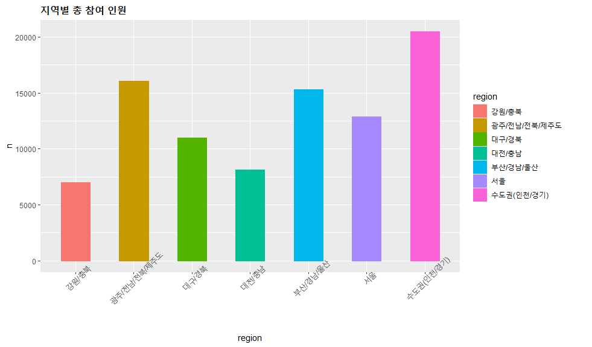

```r
ggplot(result.total_cnt,
       aes(x=region, y=n, colour=region, fill=region))+
  geom_bar(stat = "identity", width = 0.5)+
  ggtitle("지역별 총 참여 인원")+
  theme(plot.title = element_text(color = "black", size = 14, face="bold"),
        axis.text.x = element_text(angle=45))
```

#### **(3) 연도-지역별 혼인률 추이 그래프**

앞서 `연도-지역별 설문 참여`데이터를 기반으로 해당 지역의 혼인률은 얼마나 되는지 확인하였다.

단계는 다음과 같다.

우선 지역별 혼인 경험을 보유하고 있는 인원수를 모두 세어보기 위해 혼인 경험자를 필터링 하고, 이후 필터링된 데이터를 카운트 하였다.

```r
#지역별 혼인 경험 보유 인원수 Count
ma_re.2019 <- ma_re.2019 %>%
  group_by(region, marriage) %>%
  select(marriage) %>%
  filter(marriage == "marriaged") #혼인 경험자 필터링

ma_re.2019 <- ma_re.2019 %>%
  group_by(region) %>%
  tally() #혼인 경험자 카운트
```

이후 지역별로 혼인 문항 설문조사에 참여한 인원수를 모두 카운팅 한다.

```r
#지역별 혼인 설문조사 참여 인원수 Count
cnt_region.2019  <- df.2019 %>%
  group_by(region) %>%
  tally()
```

상단에 구한 값들을 토대로 백분률을 구하여 혼인률을 산정한다.

```r
#백분률 계산 -- round((A/B)*100,2)
df.m.2019 <- cbind(ma_re.2019,cnt_region.2019)
df.m.2019 <- df.m.2019[,c(1,2,4)]
df.m.2019 <- rename(df.m.2019,
                    c(n = "marriaged",
                      n.1 = "cnt"))
df.m.2019 <- data.frame(df.m.2019, percent = NA)

i <- 1
for(i in 1:7){
  df.m.2019$percent[i]<- (df.m.2019$marriaged[i]/df.m.2019$cnt[i])*100
  df.m.2019$percent<- round(df.m.2019$percent,2)
  i <- i+1
}

year.m <- rep(2019, times=7)
df.m.2019<- data.frame(year.m, df.m.2019)
```

그래프를 그리면 다음과 같이 나타난다.

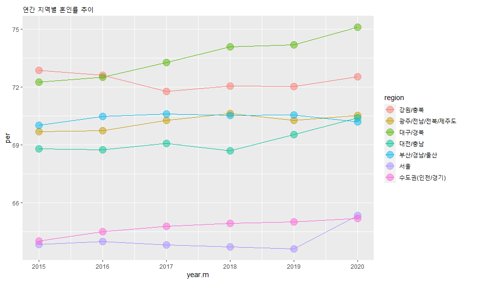

```r
#그래프 그리기
ggplot(df.region_marriage,
       aes(x=year.m, y=percent ,colour=region, group=region))+
  geom_line()+
  geom_point(size=5, shape=19, alpha=0.5)+
  ggtitle("연간 지역별 혼인률 추이")+
  ylab("per")
```

#### **(4) 지역별 혼인 경험 인구 분포**

[figure not shown]

```r
register_google(key='AIzaSyCovjI0rxava9Kchw7aHcos03VtaV_zOO8') # 부여받은 키 등록
df.wr.outlier

#area
list_region <- data.frame(area = c(1:7),
                          region= c("서울특별시",
                                    "경기도",
                                    "경상남도",
                                    "경상북도",
                                    "충청남도",
                                    "충청북도",
                                    "전라남도"))

df.wr.outlier.2 <- left_join(df.wr.outlier, list_region, id="area")

df.wr.outlier.2$group_marriage <- ifelse(df.wr.outlier.2$marriage == 1 |
                                         df.wr.outlier.2$marriage == 2 |
                                         df.wr.outlier.2$marriage == 3 |
                                         df.wr.outlier.2$marriage == 4, "marriaged",NA)
df.wr.outlier.2 <- subset(df.wr.outlier.2, df.wr.outlier.2$group_marriage == "marriaged")
df.wr.outlier.2 <- df.wr.outlier.2[,c("region", "group_marriage")]

map.region <- df.wr.outlier.2 %>%
  filter(group_marriage == "marriaged") %>%
  group_by(region) %>%
  summarise(n=n())

gc <- geocode(enc2utf8(map.region$region)) # 지점의 경도위도

df.city <- data.frame(name=map.region$region, lon= gc$lon,
                      lat=gc$lat)

cen <- c(mean(df.city$lon), mean(df.city$lat))# 경도위도를 숫자로
map <- get_googlemap(center=cen,
                     maptype="roadmap",
                     size=c(600,600),
                     zoom = 8)#지도생성

gmap <- ggmap(map) # 지도 화면에 보이기 및 저장

df.city <- rename(df.city, c(region = "name"))
map.region <- left_join(map.region, df.city, id="region")

#그래프 그리기
gmap+ geom_point(data=map.region, aes(x=lon, y=lat, col=n,size=n, stroke=10), alpha=1) + labs(col="명")  + ggtitle("전국 혼인경험 인구 분포(7구역별)")
```

### **6.장애/교육수준/건강상태 별 혼인률 추이**

- 장애수준은 2015-2019 년도까지는 총 8단계로 이루어져 있으나, 장애인 등급 제도가 폐지됨에 따라 2020년 기준 4 단계로 축소되어 2020년 기준에 맞추었음.
- 건강수준은 총 5단계의 응답으로 구성되어 있음.
- 교육수준은 미취학과 무학을 동일 취급하여 총 9단계에서 8단계로 조정하였음.

```r
dis_marriage <- df.wr.outlier %>%
  filter(!is.na(group_marriage)) %>%
  dplyr::count(dis, group_marriage) %>%
  group_by(dis) %>%
  mutate(pct = round((n/52999*100),1))

health_marriage <- df.wr.outlier %>%
  filter(!is.na(group_marriage)) %>%
  dplyr::count(health,group_marriage) %>%
  group_by(health) %>%
  mutate(pct = round((n/52999*100),1))

edu_marriage <- df.wr.outlier %>%
  filter(!is.na(group_marriage)) %>%
  dplyr::count(edu,group_marriage) %>%
  group_by(edu) %>%
  mutate(pct = round((n/52999*100),1))
```

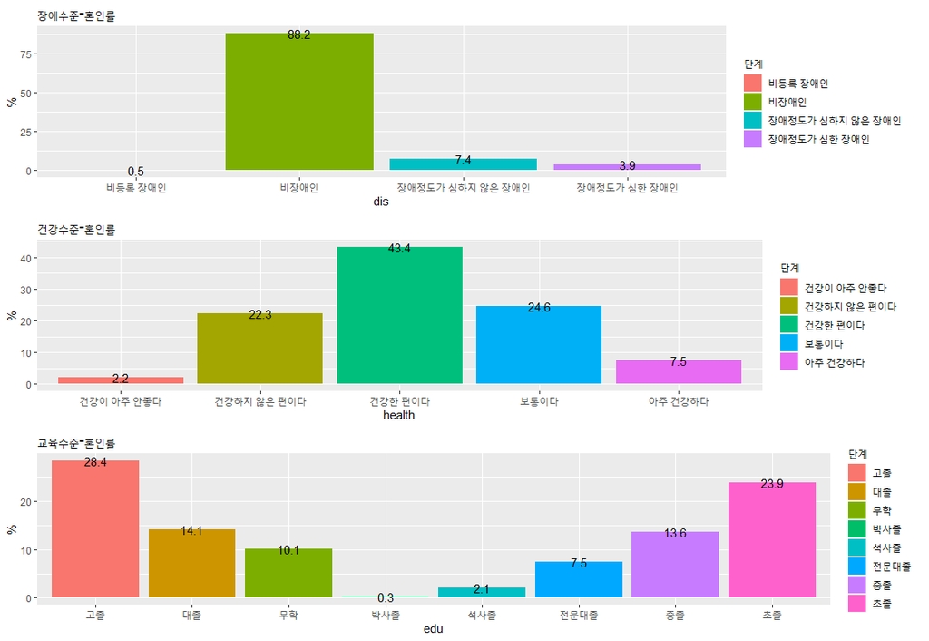

### **7.종교 유무에 따른 혼인률 비교**

종교 유무에 따른 혼인률을 비교하였다. 혼인상태의 두 변수를 전처리한 후, 집단 별 빈도를 구하여 혼인 경험 보유자들에 해당하는 값만 추출하여 혼인률 표를 만들고, 이를 이용하여 그래프를 만들었다.

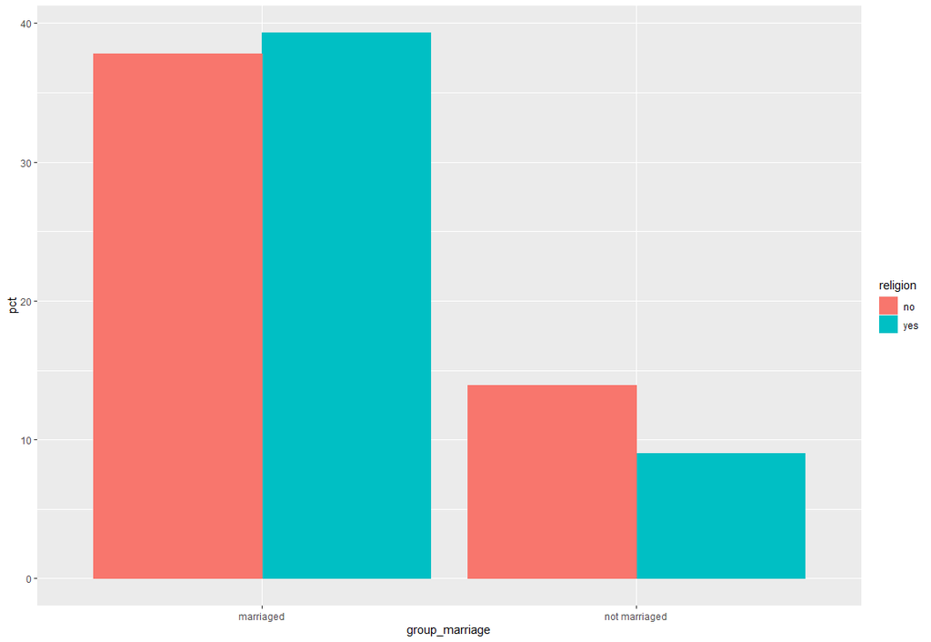

```r
###2. 종교 유무에 따른 혼인율
religion_marriage <- df.wr.outlier
df.wr.outlier$group_marriage <- ifelse(df.wr.outlier$marriage == 1 |df.wr.outlier$marriage == 2 | df.wr.outlier$marriage == 3 | df.wr.outlier$marriage == 4,
                                       "marriaged",
                                       "not marriaged")

religion_marriage <- df.wr.outlier %>%
  filter(!is.na(group_marriage)) %>%
  dplyr::count(religion, group_marriage) %>%
  group_by(religion) %>%
  mutate(pct = round(n/68733*100,1))

religion_marriage$religion <- ifelse(religion_marriage$religion == 1, "yes", "no")
religion_marriage

#그래프 그리기
ggplot(religion_marriage,
       aes(x=group_marriage, y=pct, color=religion, fill=religion))+
  geom_col(position = "dodge")
```

### **8.직업-임금-혼인유무 시각화 및 분석**

혼인률과 직접적인 연관이 있을 것이라고 생각한 직업과 관련하여 다양한 시각화 작업을 진행해 보았다. 처음에는 임금에 따른 혼인률을 분석하려 하였으나, 임금에 대한 전처리 과정에서 이상치 분석 및 정제를 통한 결과들이 분석을 하기에 어려움이 있어 다음과 같이 시각화 및 분석 작업을 진행하였다.

> - 각 직군별 응답자 수 인사이트를 확인함
> - 각 직군별 임금(연봉) 추이를 확인함
> - 직군별 혼인률에 대한 인사이트를 확인함
> - 이를 기반으로 임금과 혼인률에 대한 상관성을 유추함

```r
##직업별 응답자 상위 10, 하위 10
job_marriage.top <- df.wr.outlier %>%
  filter(!is.na(job) & group_marriage == "marriaged") %>%
  group_by(job) %>%
  dplyr::summarise(n = n()) %>%
  #mutate(pct = round((n/n*100),1)) %>%
  arrange(desc(n)) %>%
  head(10)


job_marriage.bot <- df.wr.outlier %>%
  filter(!is.na(job) & group_marriage == "marriaged") %>%
  group_by(job) %>%
  dplyr::summarise(n = n()) %>%
  arrange(n) %>%
  head(10)
```

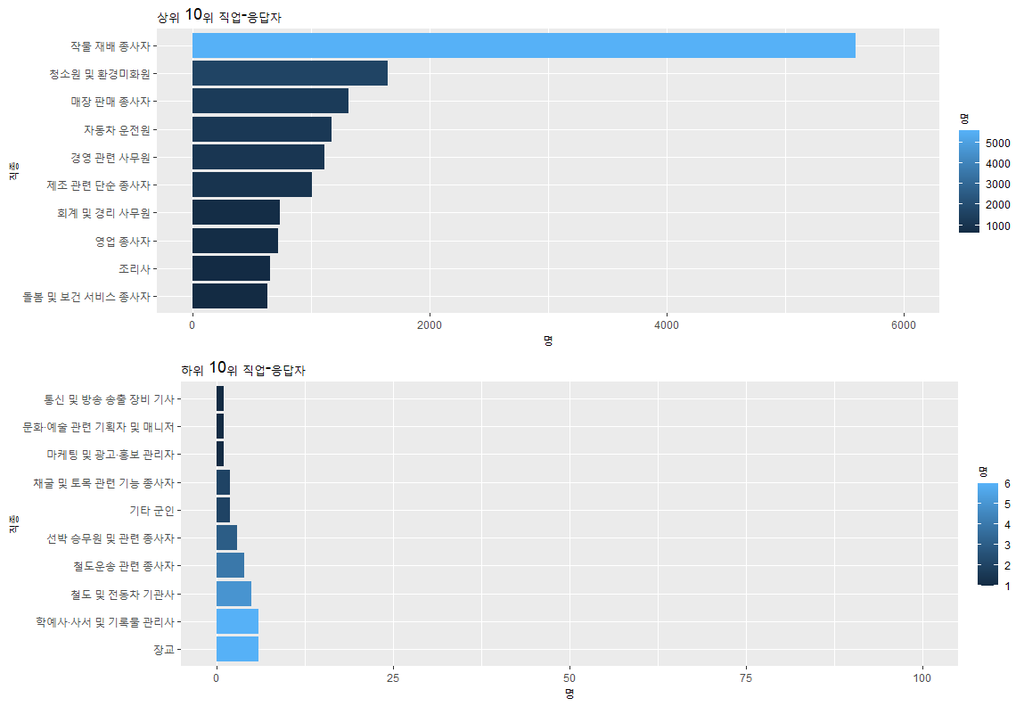

```r
##직업-연봉 상위 10, 하위 10
job_income <- df.wr.outlier %>%
  filter(!is.na(job)&!is.na(income)) %>%
  group_by(job) %>%
  dplyr::summarise(mean_income = mean(income))

head(job_income)

#top10 income-job
income.top <- job_income %>%
  arrange(desc(mean_income)) %>%
  head(10)

#bottom10 income-job
income.bot <- job_income %>%
  arrange(mean_income) %>%
  head(10)
```

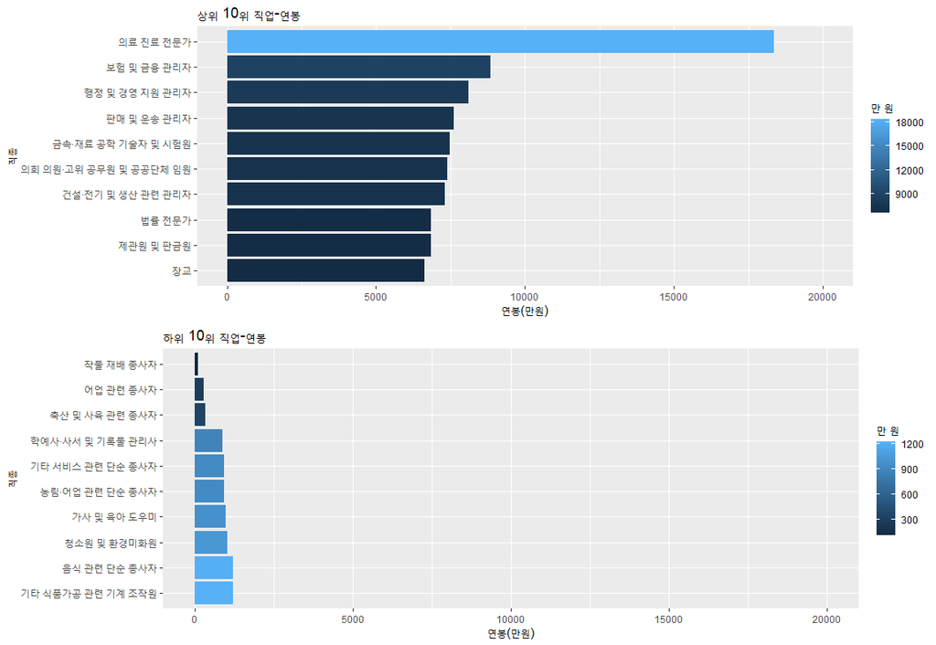

```r
##직업-혼인율 비율 구하기

#직업별 총인원 구하기
job_total <- df.wr.outlier %>%
  filter(!is.na(job)) %>%
  group_by(job) %>%
  dplyr::summarise(n=n()) %>%
  arrange(desc(n))

job_total

#직업별 혼인경험 유/무 인원 구하기
job_marriage <- df.wr.outlier %>%
  filter(!is.na(job)) %>%
  group_by(job, group_marriage) %>%
  dplyr::summarise(ans = n())

job_rate <- left_join(job_total, job_marriage, id="job")

#비율 구하기
i <- 1
no <- nrow(job_rate)
for(i in 1:no){
  job_rate$pnt[i]<- round((job_rate$ans[i]/job_rate$n[i])*100,1)
}
job_rate

fin.job_rate<- job_rate %>%
  filter(group_marriage =="marriaged") %>%
  group_by(job)

fin.job_rate <- fin.job_rate[,c(1,5,4,2)]
fin.job_rate <- arrange(fin.job_rate, desc(pnt))

top30 <- fin.job_rate[c(1:15),]

fin.job_rate <- arrange(fin.job_rate, pnt)
bot30 <- fin.job_rate[c(1:15),]
```

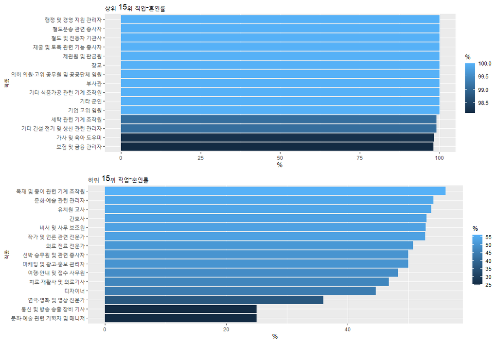

### **9. 나이-혼인 정도 시각화 및 분석**

마지막으로 나이에 따른 혼인경험 유무에 대해 시각화를 진행하였다. 설문조사에 참여한 나이별로 인원들을 확인하였고, 이에 대해 결혼여부를 확인하였다. 이후 결혼 여부에 대한 응답자를 히스토그램으로 나타내어 두 결과를 중첩한 형태의 모습으로 제시하여 그 혼인 경험 유무의 비중이 연령대 별로 얼마나 많이 차지하고 있는지를 확인할 수 있도록 하였다.

```r
#설문조사에 참여한 나이별 인원 확인
df.birth.1 <- df.birth %>%
  group_by(age) %>%
  dplyr::summarise(total = n())

#나이별 결혼여부 확인
df.birth.rate <- df.birth %>%
  group_by(age, group_marriage) %>%
  dplyr::summarise(n = n())
```

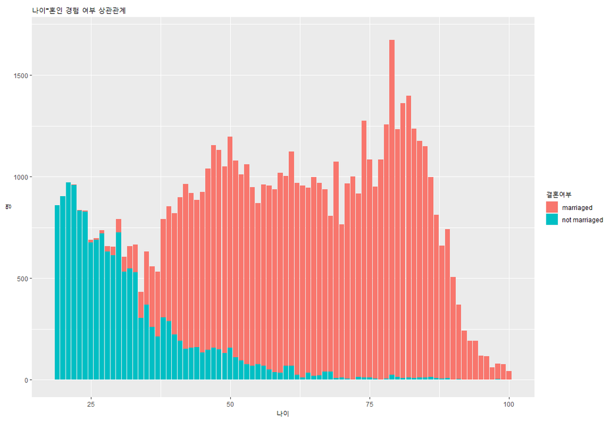

### **Conclusion**

시각화를 진행하면서 다양한 데이터들을 전처리, 시각화, 분석을 진행해보았다.

처음 분석 및 시각화 설계는 다음과 같이 진행하려고 하였다.

- 시계열에 따른 혼인률 변화 시각화 및 분석
- 지역별 혼인율 편차 변화 시각화 및 분석
- 그렇다면 혼인율에 영향을 미치는 요인은 무엇인가?
- 각 문항별 변수간의 산점도를 기반으로 하여 상관성 분석을 통해 혼인율에 가장 큰 영향을 미치는 요인을 알아보고 이와 관련하여 특정 변수에 대한 추가적인 시각화를 진행

그러나 생각보다 단순히 `pairs()`함수를 사용한다고 해서, 그리고 위에서 일부 언급한 것과 같이 임금과 같은 변수의 경우 이상치 처리가 까다로워 분석을 할 수 있는 상관관계를 나타내고 있는 수치 혹은 그래프가 나타나지 않았다.

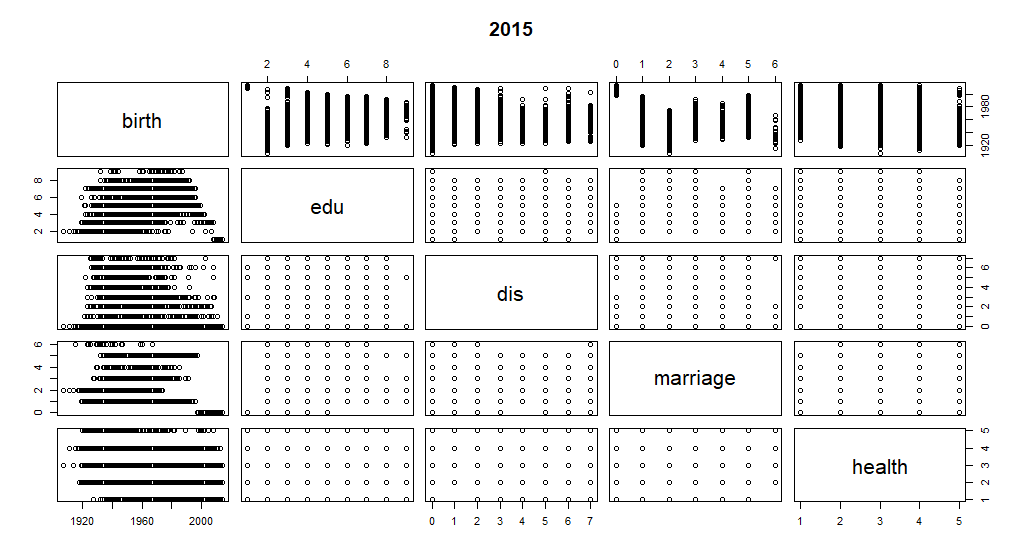

pairs_fail

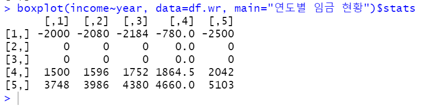

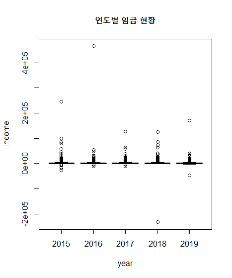

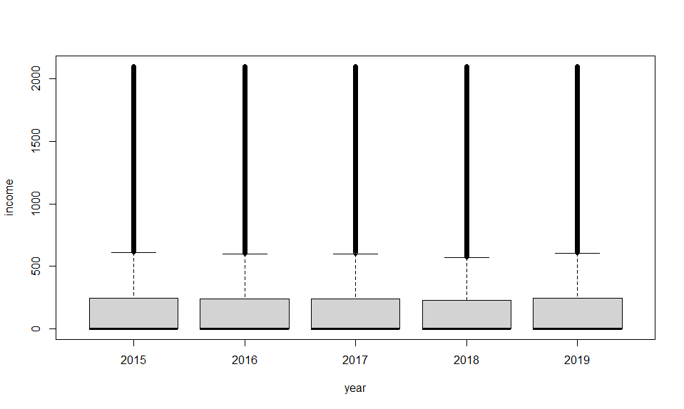

`pairs()`를 통해서 판단하였을 때, 회귀분석 등의 솔루션도 현재 데이터의 상태로는 무의미할 것으로 판단이 되고, 아직 정제를 어떤 방향으로 해야할지, 어떤 기법들을 써야할지 아직 방향을 잡지 못하여 이번에 R을 처음 접하면서 현재 할 수 있는 것들을 기반으로 진행을 해 보았다.

#### **R codes**

본 과제의 소스코드는 `Github`에 모두 공개되어 있으며, 소스코드 및 사용한 데이터셋을 모두 확인할 수 있습니다.

- **Github URL : https://github.com/wpsl94/DataMining_Mid-2021**